# Course 5 Week 2 Assignment

Ibrahim Yucel

February 19, 2017

Loading and preprocessing the data

```r
activity <- read.csv("activity.csv")
```

# What is mean total number of steps taken per day?

1. Calculate the total number of steps taken per day

```r
#use the tapply function for this
total_steps <- tapply(activity$steps, activity$date, sum, na.rm=TRUE)
```

2. Make a histogram of the total number of steps taken each day

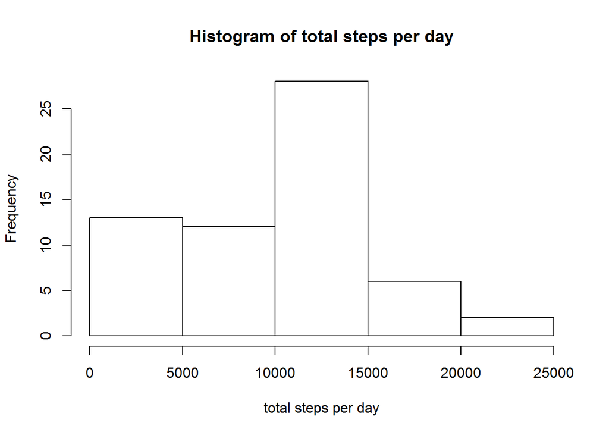

```r
hist(total_steps, main="Histogram of total steps per day", xlab="total steps per day")
```

3. Calculate and report the mean and median of the total number of steps taken per day

```r
mean_steps <-mean(total_steps)
median_steps<-median(total_steps)
```

The mean is 9354 and the median is 10395.

# What is the average daily activity pattern?

1. Make a time series plot (i.e. type = “l”) of the 5-minute interval (x-axis) and the average number of steps taken, averaged across all days (y-axis)

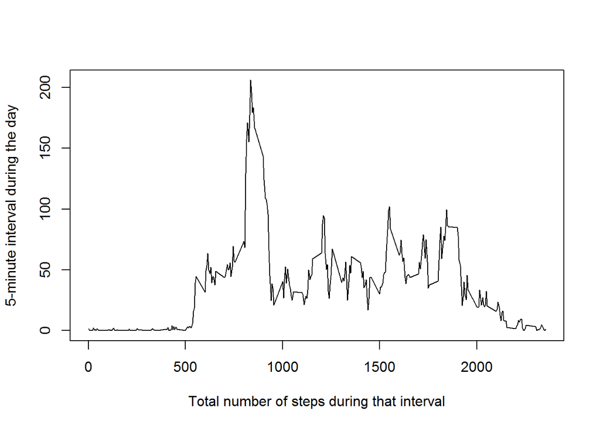

```r
interval_steps <- tapply(activity$steps, activity$interval, mean, na.rm=TRUE)
plot(interval_steps~unique(activity$interval), type="l", ylab="5-minute interval during the day", xlab="Total number of steps during that interval")
```

2. Which 5-minute interval, on average across all the days in the dataset, contains the maximum number of steps?

```r
max_interval <- interval_steps[which.max(interval_steps)]
max_interval<- as.data.frame((max_interval))
```

The 5-minute interval in which the most steps are taken is interval 835, when an average of 206 steps are taken

# Inputing missing values

1. Calculate and report the total number of missing values in the dataset (i.e. the total number of rows with NAs)

```r
missing <- table(is.na(activity)==TRUE)
missing<-missing[2]
```

There are 2304 missing values in this data set.

2. Devise a strategy for filling in all of the missing values in the dataset. The strategy does not need to be sophisticated. For example, you could use the mean/median for that day, or the mean for that 5-minute interval, etc.

The method of intrapolation I used was to find the average number of steps over the entire two-month period for all 5-minute intervals, and then apply that average to the 5-mimnute observations with missing values. It is reasonable to assume that this anonymous individual has a regular routine that can averaged out over the course of two months, so for example, if he/she generally walks about 200 steps around 6pm every day, we can assume that that value also applies for any 5-minute intervals around 6pm with missing values.

```r
#Use a for loop for each 5-minute interval and put the results into a separate table, then apply the results of the table to a new dataset with no missing values
activities <- activity
mean_steps <- tapply(activity$steps, activity$interval, mean, na.rm=TRUE)
for (i in 1:nrow(activity)){
  if(is.na(activity$steps[i])){
    activities$steps[i] <- mean_steps[[as.character(activity[i, "interval"])]]
  }
}
```

After accounting for the missing values, the new histogram of steps per day is as follows:

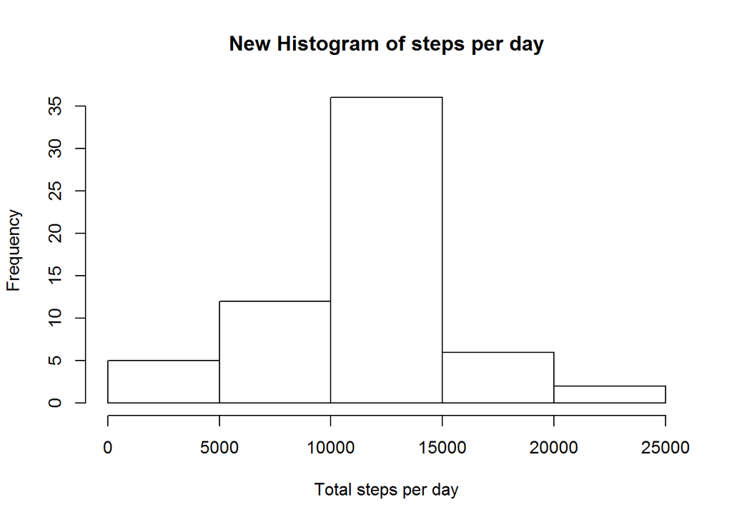

```r
histogram2<-tapply(activities$steps, activities$date, sum)
hist(histogram2, main="New Histogram of steps per day", xlab="Total steps per day")
```

# Are there differences in activity patterns between weekdays and weekends?

Create a new factor variable in the dataset with two levels - “weekday” and “weekend” indicating whether a given date is a weekday or weekend day.

```r
#activities$weekday <-c("weekday")
activities$weekdays <- weekdays(as.Date(activities$date))
activities$weekdays<-ifelse(activities$weekdays %in% c("Saturday", "Sunday"), "weekend", "weekday")
```

Make a panel plot containing a time series plot (i.e. type = “l”) of the 5-minute interval (x-axis) and the average number of steps taken, averaged across all weekday days or weekend days (y-axis).

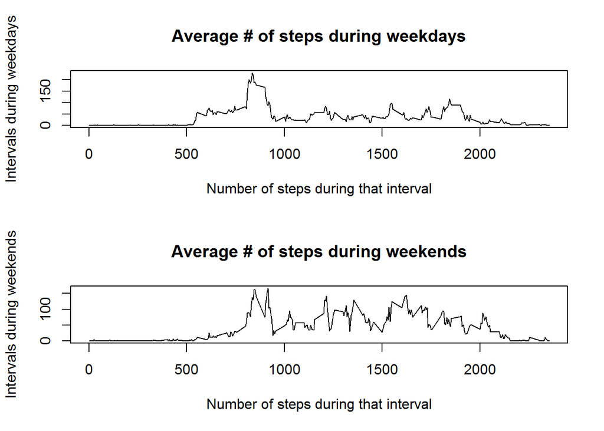

```r
weekend_activities<-activities[ which(activities$weekdays=="weekend"),]
weekday_activities<-activities[ which(activities$weekdays=="weekday"),]

average_weekends <- tapply(weekend_activities$steps, weekend_activities$interval, mean, na.rm=TRUE)

average_weekdays <- tapply(weekday_activities$steps, weekday_activities$interval, mean, na.rm=TRUE)

#average_weekdays <- tapply(activities$steps, activities$weekdays, mean, na.rm=TRUE)

par(mfrow=c(2,1))

plot(average_weekdays~unique(weekday_activities$interval), type="l", ylab="Intervals during weekdays", main= "Average # of steps during weekdays", xlab="Number of steps during that interval")

plot(average_weekends~unique(weekend_activities$interval), type="l", ylab="Intervals during weekends", main="Average # of steps during weekends", xlab="Number of steps during that interval")
```